# Notebook

## Contact Details

**Dr. Mahmud Muhammad**  
(PhD, MSc, and BSc in Geology)  
Email: mahmud.geology@hotmail.com  
Website: mahmudm.com

## Objective

The goal of this project is to develop a suite of probability density functions (PDFs) that describe Eruption Source Parameter (ESP) inputs required by the NAME model. These estimations are crucial for accurate volcanic ash dispersion modeling.

### Key Tasks:

1. **Automated Retrieval and Parsing of Volcanic Advisory Reports (VAA):**
   - Implement a system to automatically retrieve and parse real-time Volcanic Advisory Reports (VAA) from the Tokyo Volcanic Ash Advisory Center (TVAAC).
2. **Annual VEI Probability Parsing:**
   - Utilize the methodology outlined in Whelley et al. (2015) to extract annual Volcanic Explosivity Index (VEI) probabilities for the volcano of concern using data from VAA reports.
3. **Bayesian Sampling for Total Eruption Mass (TEM):**
   - Estimate the range of Total Eruption Mass (TEM) for a known VEI level using Bayesian probability sampling. This estimation will account for a range of tephra particl densities.
4. **Mass Eruption Rate (MER) Estimation:**
   - Calculate the Mass Eruption Rate (MER) based on the derived Total Eruption Mass (TEM).
5. **Eruption Duration Calculation:**
   - Derive the eruption duration by integrating the MER and TEM values.
6. **Plume Height Estimation from MER:**
   - Estimate the volcanic plume height using the Mass Eruption Rate (MER).
7. **MER Estimation from Plume Height:**
   - Estimate the MER using observed Plume Height.
8. **Estimation of Mass fraction of ash particle size below 63 microns:**
   - Estimate the Mass fraction of ash particle size below 63 microns using the Mass Eruption Rate (MER).

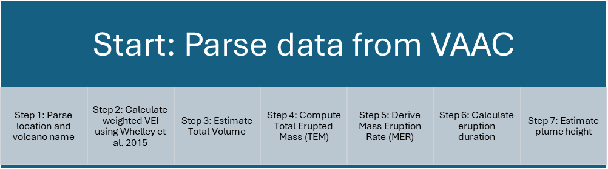

# **Parsing of Volcanic Advisory Reports (VAA)**

```python
# Using Whelley et al., 2015  paper that calculated VEI Level eruption for 750 volcanoes in southeast Asia we start estimating Eruption source paramerters from VEI and probablistic volume estimates.

# first we load Whelley 2015 Volcano Database later will be use to filter Volcanish Ash Advisory reports from Tokyo Volcanic Ash Advisory Center in realtime (computer need internet connection to parse VAA reports)

import vei

data_loader=vei.LOADDATA()


whelley_data=data_loader.whelley_2015(as_geodataframe=True)
```

```python
# import Libraries and classes required to parse VAA reports and filter dataset for later use.

import vep_vaa_text
from vep_vaa_text import VEP_TVAAC_VAAText
scraper = VEP_TVAAC_VAAText()
scraper.fetch_webpage()
tables = scraper.extract_all_tables()
tables
# Perform a search Note: for realtime operation set all parameters to None to retrive the latest report VAA report
search_results = scraper.search(query='SINABUNG', date_time=None, advisory_number='2020')  # Replace with your query string, set all parameters to None to retrive latest report dates: Note takes longer processing time
downloaded_VAA_report, latest_VAA_report , latest_date_data=scraper.download_vaa_text(output_dir="./vaa_texts_2", filtered_results=search_results, csv=True, gdf=whelley_data)

downloaded_VAA_report.head(2)
```

```
CSV file created: ./vaa_texts_2\vaa_texts.csv
```

|  | DTG | VAAC | VOLCANO | VOLCANO CODE | PSN | AREA | SUMMIT ELEV | ADVISORY NR | INFO SOURCE | AVIATION COLOUR CODE | ... | FCST VA CLD +6 HR | FCST VA CLD +12 HR | FCST VA CLD +18 HR | RMK | NXT ADVISORY | Latitude | Longitude | ADVISORY_YEAR | REPORT_NUMBER | DTG_DATETIME |
| --- | --- | --- | --- | --- | --- | --- | --- | --- | --- | --- | --- | --- | --- | --- | --- | --- | --- | --- | --- | --- | --- |
| 0 | 20200810/1635Z | DARWIN | SINABUNG | 261080 | N0310 E09824 | INDONESIA | 2460M | 2020/12 | HIMAWARI-8, CVGHM, PIREP, WEBCAM | RED | ... | 10/2235Z NO VA EXP | 11/0435Z NO VA EXP | 11/1035Z NO VA EXP | VA TO FL320 LAST PARTIALLY OBS ON SAT IMAGERY ... | NO LATER THAN 20200810/2235Z= | 3.166667 | 98.4 | 2020 | 12 | 2020-08-10 16:35:00 |
| 1 | 20200810/1030Z | DARWIN | SINABUNG | 261080 | N0310 E09824 | INDONESIA | 2460M | 2020/10 | HIMAWARI-8, CVGHM, PIREP, WEBCAM | RED | ... | 10/1630Z SFC/FL140 N0303 E09852 - N0337 | 10/2230Z SFC/FL140 N0253 E10049 - N0348 | 11/0430Z NO VA EXP | ERUPTION HAS CEASED. VA TO FL320 LAST PARTIALL... | NO LATER THAN 20200810/1630Z= | 3.166667 | 98.4 | 2020 | 10 | 2020-08-10 10:30:00 |

2 rows × 23 columns

```python
latest_date_data
```

|  | DTG | VAAC | VOLCANO | VOLCANO CODE | PSN | AREA | SUMMIT ELEV | ADVISORY NR | INFO SOURCE | AVIATION COLOUR CODE | ... | FCST VA CLD +12 HR | FCST VA CLD +18 HR | RMK | NXT ADVISORY | Latitude | Longitude | ADVISORY_YEAR | REPORT_NUMBER | DTG_DATETIME | Altitude_Meters |
| --- | --- | --- | --- | --- | --- | --- | --- | --- | --- | --- | --- | --- | --- | --- | --- | --- | --- | --- | --- | --- | --- |
| 0 | 20200810/1635Z | DARWIN | SINABUNG | 261080 | N0310 E09824 | INDONESIA | 2460M | 2020/12 | HIMAWARI-8, CVGHM, PIREP, WEBCAM | RED | ... | 11/0435Z NO VA EXP | 11/1035Z NO VA EXP | VA TO FL320 LAST PARTIALLY OBS ON SAT IMAGERY ... | NO LATER THAN 20200810/2235Z= | 3.09 | 9.92 | 2020 | 12 | 2020-08-10 16:35:00 | 4267.2 |

1 rows × 24 columns

```python
# Retrive data from the latest report date
from rich.console import Console
from rich.table import Table

# Initialize the console
console = Console()

# Create a table for a professional and structured output
table = Table(title="Volcanic Activity Observations", show_lines=True, title_style="bold blue")

# Define table columns
table.add_column("Parameter", style="dim", width=25)
table.add_column("Value", style="bold white", justify="center")

# Populate the table with data, if available
if 'VOLCANO' in latest_date_data.columns:
    volcano_name = latest_date_data['VOLCANO'].to_list()[0]
    table.add_row("Site of Volcanic Activity", volcano_name)

if 'Altitude_Meters' in latest_date_data.columns:
    observed_ash_altitude_meter = latest_date_data['Altitude_Meters'].to_list()[0]
    table.add_row("Observed Ash Altitude (m ASL)", str(observed_ash_altitude_meter))

if 'Latitude' in latest_date_data.columns:
    latitude = latest_date_data['Latitude'].to_list()[0]
    table.add_row("Latitude", str(latitude))

if 'Longitude' in latest_date_data.columns:
    longitude = latest_date_data['Longitude'].to_list()[0]
    table.add_row("Longitude", str(longitude))



# Call the search_whelley_2015 method on the instance
search_results, vei_range = data_loader.search_whelley_2015(Volcano=volcano_name, max_vei_returns=None)

# View the search results
#print(f"Potential VEI Levels for  Volcano site {volcano_name} is based on Whelley et al. 2015 paper   {vei_range}")
#print(search_results)

table.add_row(f"Possible VEI Levels for  Volcano  {volcano_name}  based on Whelley et al. 2015 paper", str(vei_range))

# Render the table
console.print(table)

import pandas as pd
import plotly.graph_objects as go

search_results = pd.DataFrame(search_results)

# Create a table
fig = go.Figure(data=[go.Table(
    header=dict(values=list(search_results.columns),
                fill_color='paleturquoise',
                align='left'),
    cells=dict(values=[search_results[col] for col in search_results.columns],
               fill_color='lavender',
               align='left'))
])

# Add a bold title
fig.update_layout(
    title=dict(
        text=f"Search Results for Whelley et al. 2015 show possible VEI activity for the volcano {volcano_name}",
        x=0.5,  # Center the title
        font=dict(size=20, family="Arial Black", color="black")  # Use bold font family
    )
)

fig.show()
```

```
Top VEI values returned: [2, 3, 4, 5]
```

```
       Volcanic Activity Observations
┏━━━━━━━━━━━━━━━━━━━━━━━━━━━┳━━━━━━━━━━━━━━┓
┃ Parameter                 ┃    Value     ┃
┡━━━━━━━━━━━━━━━━━━━━━━━━━━━╇━━━━━━━━━━━━━━┩
│ Site of Volcanic Activity │   SINABUNG   │
├───────────────────────────┼──────────────┤
│ Observed Ash Altitude (m  │    4267.2    │
│ ASL)                      │              │
├───────────────────────────┼──────────────┤
│ Latitude                  │     3.09     │
├───────────────────────────┼──────────────┤
│ Longitude                 │     9.92     │
├───────────────────────────┼──────────────┤
│ Possible VEI Levels for   │ [2, 3, 4, 5] │
│ Volcano  SINABUNG  based  │              │
│ on Whelley et al. 2015    │              │
│ paper                     │              │
└───────────────────────────┴──────────────┘
```

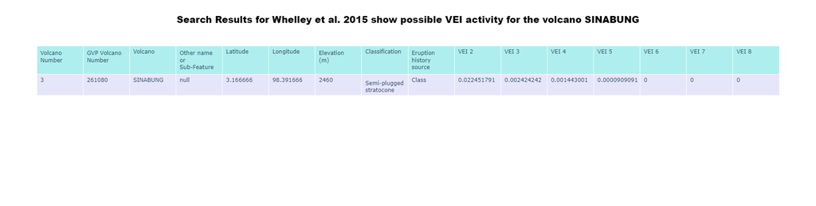

# Step 1: Define Total Eruption Mass (TEM) from VEI

This cell initializes the `VEI_BulkVolume_Mass` class to perform probabilistic calculations of total eruption mass based on known VEI values.

## Outcome:

The `vei_toMass` object enables generating probabilistic TEM values for subsequent calculations.

```
Generating probabilistic volumes...
Probabilistic volumes successfully generated.
Best density sampling strategy: normal
### Volume Percentiles ###
   VEI  emp_Volume_5th  Uncertainty_emp_Volume_5th  Prob_Volume_5th  \
0    0       2300000.0                    230000.0     2.528941e+07
1    1       2300000.0                    230000.0     2.528941e+07
2    2       2300000.0                    230000.0     2.528941e+07
3    3       2300000.0                    230000.0     2.528941e+07
4    4       2300000.0                    230000.0     2.528941e+07
5    5       2300000.0                    230000.0     2.528941e+07
6    6       2300000.0                    230000.0     2.528941e+07
7    7       2300000.0                    230000.0     2.528941e+07
8    8       2300000.0                    230000.0     2.528941e+07

   Uncertainty_Prob_Volume_5th  emp_Volume_25th  Uncertainty_emp_Volume_25th  \
0                 2.528941e+06      100000000.0                   10000000.0
1                 2.528941e+06      100000000.0                   10000000.0
2                 2.528941e+06      100000000.0                   10000000.0
3                 2.528941e+06      100000000.0                   10000000.0
4                 2.528941e+06      100000000.0                   10000000.0
5                 2.528941e+06      100000000.0                   10000000.0
6                 2.528941e+06      100000000.0                   10000000.0
7                 2.528941e+06      100000000.0                   10000000.0
8                 2.528941e+06      100000000.0                   10000000.0

   Prob_Volume_25th  Uncertainty_Prob_Volume_25th  emp_Volume_50th  ...  \
0      5.498412e+08                  5.498412e+07     3.000000e+10  ...
1      5.498412e+08                  5.498412e+07     3.000000e+10  ...
2      5.498412e+08                  5.498412e+07     3.000000e+10  ...
3      5.498412e+08                  5.498412e+07     3.000000e+10  ...
4      5.498412e+08                  5.498412e+07     3.000000e+10  ...
5      5.498412e+08                  5.498412e+07     3.000000e+10  ...
6      5.498412e+08                  5.498412e+07     3.000000e+10  ...
7      5.498412e+08                  5.498412e+07     3.000000e+10  ...
8      5.498412e+08                  5.498412e+07     3.000000e+10  ...

   Prob_Volume_50th  Uncertainty_Prob_Volume_50th  emp_Volume_75th  \
0      5.496897e+10                  5.496897e+09     5.000000e+11
1      5.496897e+10                  5.496897e+09     5.000000e+11
```

[output cut: 99 more lines]

```
+-------+-------------------+----------------------------+--------------------------------+--------------------+-------------------+---------------------+--------------------+------------------+------------------------------+-------------------+-------------------------------+-------------------+---…
| mean  |          459.234  |                4.59234e+11 |                    6.7898e+13  |        4.59239e+14 |       5.30198e+13 |         7.37022e+16 |        1.23764e+16 |          2.3e+06 |                       230000 |       2.52894e+07 |                   2.52894e+06 |             1e+08 |   …
+-------+-------------------+----------------------------+--------------------------------+--------------------+-------------------+---------------------+--------------------+------------------+------------------------------+-------------------+-------------------------------+-------------------+---…
| std   |          837.619  |                8.37619e+11 |                    1.81682e+14 |        8.37632e+14 |       9.66937e+13 |         1.97212e+17 |        3.3116e+16  |          0       |                            0 |       3.95127e-09 |                   0           |             0     |   …
+-------+-------------------+----------------------------+--------------------------------+--------------------+-------------------+---------------------+--------------------+------------------+------------------------------+-------------------+-------------------------------+-------------------+---…
| min   |            0.0005 |           500000           |                    5.50227e+06 |        4.99982e+08 |       5.77406e+07 |         5.97306e+09 |        1.00317e+09 |          2.3e+06 |                       230000 |       2.52894e+07 |                   2.52894e+06 |             1e+08 |   …
+-------+-------------------+----------------------------+--------------------------------+--------------------+-------------------+---------------------+--------------------+------------------+------------------------------+-------------------+-------------------------------+-------------------+---…
| 25%   |            0.1    |                1e+08       |                    5.49841e+08 |        9.99968e+10 |       1.15475e+10 |         5.96962e+11 |        1.00256e+11 |          2.3e+06 |                       230000 |       2.52894e+07 |                   2.52894e+06 |             1e+08 |   …
+-------+-------------------+----------------------------+--------------------------------+--------------------+-------------------+---------------------+--------------------+------------------+------------------------------+-------------------+-------------------------------+-------------------+---…
| 50%   |           30      |                3e+10       |                    5.4969e+10  |        3.00003e+13 |       3.46484e+12 |         5.96677e+13 |        1.0021e+13  |          2.3e+06 |                       230000 |       2.52894e+07 |                   2.52894e+06 |             1e+08 |   …
+-------+-------------------+----------------------------+--------------------------------+--------------------+-------------------+---------------------+--------------------+------------------+------------------------------+-------------------+-------------------------------+-------------------+---…
| 75%   |          500      |                5e+11       |                    5.49918e+12 |        5.00004e+14 |       5.77352e+13 |         5.96994e+15 |        1.00278e+15 |          2.3e+06 |                       230000 |       2.52894e+07 |                   2.52894e+06 |             1e+08 |   …
+-------+-------------------+----------------------------+--------------------------------+--------------------+-------------------+---------------------+--------------------+------------------+------------------------------+-------------------+-------------------------------+-------------------+---…
| max   |         2500      |                2.5e+12     |                    5.50006e+14 |        2.50005e+15 |       2.88584e+14 |         5.9702e+17  |        1.00252e+17 |          2.3e+06 |                       230000 |       2.52894e+07 |                   2.52894e+06 |             1e+08 |   …
+-------+-------------------+----------------------------+--------------------------------+--------------------+-------------------+---------------------+--------------------+------------------+------------------------------+-------------------+-------------------------------+-------------------+---…
```

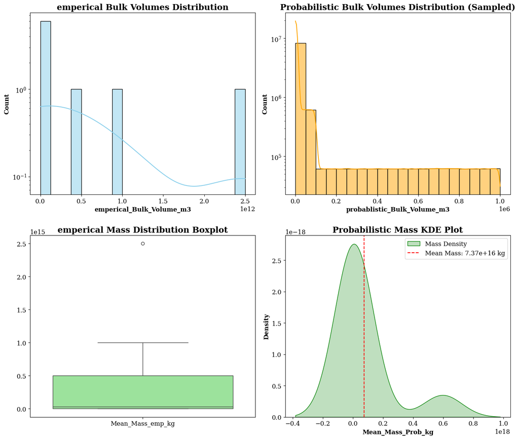

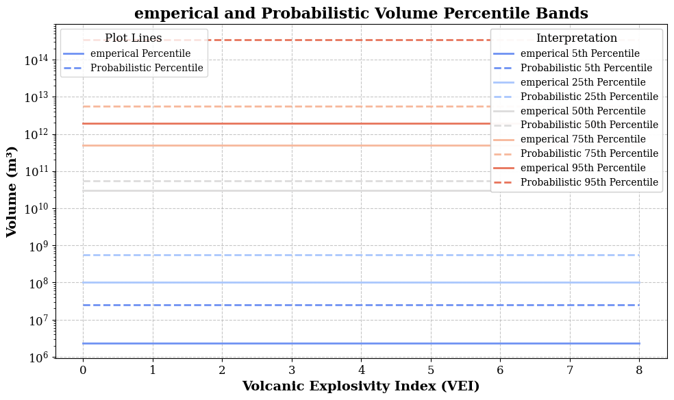

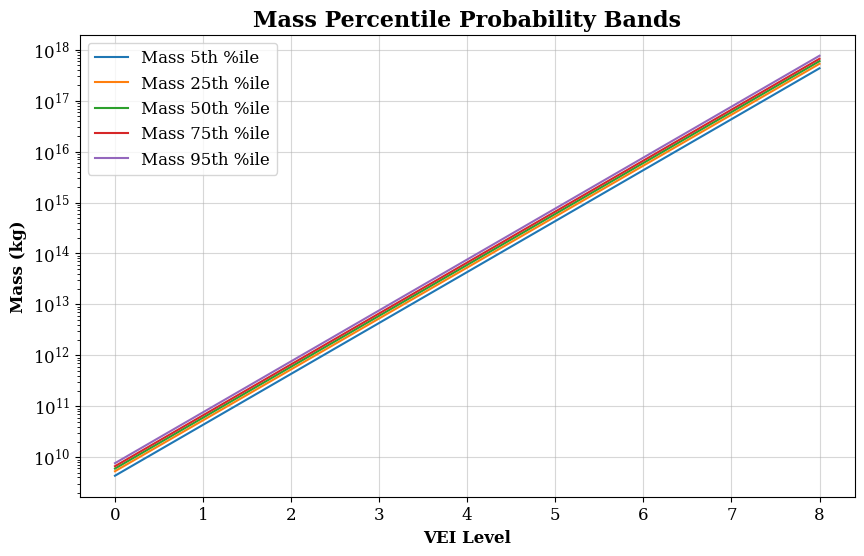

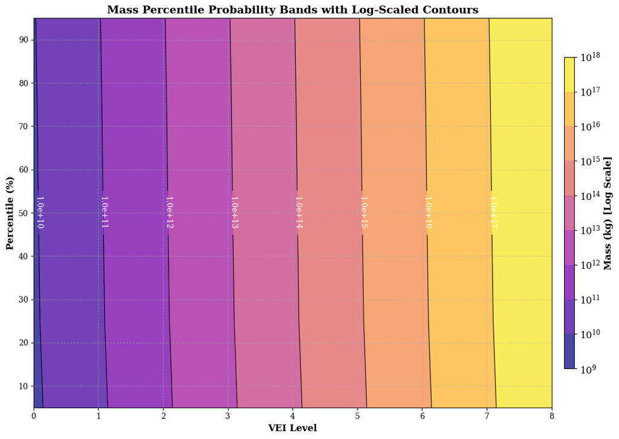

```
Volume data successfully exported to volumes_data.csv
Mass data successfully exported to masses_data.csv
Data successfully exported to VEI_MASS_VolumeResults.csv
```

```python
from vei import VEI_BulkVolume_Mass

# Initialize the class
vei_toMass = VEI_BulkVolume_Mass(use_default_densities=False, density_min=800, density_max=1200, num_samples=10000000)


# Generate probabilistic volumes
vei_toMass.generate_probabilistic_volumes()

# Calculate masses using probabilistic volumes
vei_toMass.calculate_mass(calculate_emperical=True, calculate_probabilistic=True)

vei_toMass.calculate_percentile_bands()



# # Generate summary statistics
vei_toMass.generate_summary_statistics()

# # Visualize the results
vei_toMass.visualize_statistics()

# # Calculate and plot percentile bands

vei_toMass.plot_percentile_bands()

# # Export results
#vei_toMass.export_statistics(filename="summary_statistics.csv")
vei_toMass.export_volumes_and_masses()

vei_toMass.export_data()

#vei_toMass.save_outputs_to_pdf()
```

# Step 2: Load Volcanic Data for Model Inputs and Validation

This cell loads datasets containing eruption source parameters and metadata.

## Data Sources:

1. `Mastin`: Dataset of VEI-related eruption parameters.
2. `Aubrey`: Dataset with parameters for eruption dynamics.
3. `IVESPA`: Integrated Volcanic Eruption Source Parameters Archive for further modeling.

## Purpose:

- These datasets provide observational constraints and inputs for modeling eruption parameters.
- Support statistical analysis and correlation studies to validate models.

```python
import vei
from vei import  analyze_correlations

data_loader=vei.LOADDATA()


Mastin = data_loader.load_Mastin(as_geodataframe=False)
Aubrey=data_loader.load_Aubry(as_geodataframe=False)
IVESPA=data_loader.load_IVESPA(as_geodataframe=False)
Sparks=data_loader.load_Sparks(as_geodataframe=False)
mastin_a=data_loader.load_Mastin_a(as_geodataframe=True)

# analyze_correlations(Mastin, 'Mastin', threshold=0.7)

# analyze_correlations(Aubrey, 'Aubrey', threshold=0.7)

# analyze_correlations(Sparks, 'Sparks', threshold=0.7)

# analyze_correlations(IVESPA, 'IVESPA', threshold=0.7)

#analyze_correlations(mastin_a, 'IVESPA', threshold=0.9)

import pandas as pd

Combined_datasets= pd.concat([ Aubrey, IVESPA, mastin_a], axis=0, join='inner')

aubrey_datacombined= pd.concat([ Aubrey, IVESPA], axis=0, join='inner')
```

# Step 3: Estimate Mass Eruption Rate (MER)

This cell prepares TEM data for use with the `MERPredictor` class.

## Purpose:

- `tem_values` serve as input to estimate MER, an essential eruption source parameter.
- MER will be used in subsequent steps to calculate eruption duration and plume rise.

```python
import pandas as pd

data=vei_toMass.data

# Drop first row (VEI zero) because VEI zero is None Explosive

#data = data.drop(index=data.index[0]).reset_index(drop=True)


# Ensuring the VEI column is numeric
data['VEI'] = pd.to_numeric(data['VEI'], errors='coerce')

# Filtering the dataframe based on VEI column and list
data = data[data['VEI'].isin(vei_range)].reset_index(drop=True)

data
```

|  | VEI | Bulk_Volume_km3 | emperical_Bulk_Volume_m3 | Probabilistic_Bulk_Volume_m3 | Mean_Mass_emp_kg | Std_Mass_emp_kg | Mean_Mass_Prob_kg | Std_Mass_Prob_kg | emp_Volume_5th | Uncertainty_emp_Volume_5th | ... | emp_Volume_95th | Uncertainty_emp_Volume_95th | Prob_Volume_95th | Uncertainty_Prob_Volume_95th | Mass_5th | Mass_25th | Mass_50th | Mass_75th | Mass_95th | 90%_interpercentile_Mass_Estimate |
| --- | --- | --- | --- | --- | --- | --- | --- | --- | --- | --- | --- | --- | --- | --- | --- | --- | --- | --- | --- | --- | --- |
| 0 | 2 | 0.1 | 1.000000e+08 | 5.500434e+08 | 1.000021e+11 | 1.154804e+10 | 5.971176e+11 | 1.003206e+11 | 2300000.0 | 230000.0 | ... | 1.900000e+12 | 1.900000e+11 | 3.522455e+14 | 3.522455e+13 | 4.321832e+11 | 5.294759e+11 | 5.970752e+11 | 6.647686e+11 | 7.621995e+11 | 3.300163e+11 |
| 1 | 3 | 3.0 | 3.000000e+09 | 5.502371e+09 | 2.999953e+12 | 3.464152e+11 | 5.973516e+12 | 1.003485e+12 | 2300000.0 | 230000.0 | ... | 1.900000e+12 | 1.900000e+11 | 3.522455e+14 | 3.522455e+13 | 4.323738e+12 | 5.296897e+12 | 5.973094e+12 | 6.650092e+12 | 7.624805e+12 | 3.301067e+12 |
| 2 | 4 | 30.0 | 3.000000e+10 | 5.500256e+10 | 2.999957e+13 | 3.464464e+12 | 5.970940e+13 | 1.003092e+13 | 2300000.0 | 230000.0 | ... | 1.900000e+12 | 1.900000e+11 | 3.522455e+14 | 3.522455e+13 | 4.321492e+13 | 5.294634e+13 | 5.970905e+13 | 6.647528e+13 | 7.620809e+13 | 3.299317e+13 |
| 3 | 5 | 100.0 | 1.000000e+11 | 5.498882e+11 | 9.999955e+13 | 1.154736e+13 | 5.969182e+14 | 1.002678e+14 | 2300000.0 | 230000.0 | ... | 1.900000e+12 | 1.900000e+11 | 3.522455e+14 | 3.522455e+13 | 4.319571e+14 | 5.292828e+14 | 5.969258e+14 | 6.645503e+14 | 7.618505e+14 | 3.298934e+14 |

4 rows × 34 columns

```python
data.columns
```

```
Index(['VEI', 'Bulk_Volume_km3', 'emperical_Bulk_Volume_m3',
       'Probabilistic_Bulk_Volume_m3', 'Mean_Mass_emp_kg', 'Std_Mass_emp_kg',
       'Mean_Mass_Prob_kg', 'Std_Mass_Prob_kg', 'emp_Volume_5th',
       'Uncertainty_emp_Volume_5th', 'Prob_Volume_5th',
       'Uncertainty_Prob_Volume_5th', 'emp_Volume_25th',
       'Uncertainty_emp_Volume_25th', 'Prob_Volume_25th',
       'Uncertainty_Prob_Volume_25th', 'emp_Volume_50th',
       'Uncertainty_emp_Volume_50th', 'Prob_Volume_50th',
       'Uncertainty_Prob_Volume_50th', 'emp_Volume_75th',
       'Uncertainty_emp_Volume_75th', 'Prob_Volume_75th',
       'Uncertainty_Prob_Volume_75th', 'emp_Volume_95th',
       'Uncertainty_emp_Volume_95th', 'Prob_Volume_95th',
       'Uncertainty_Prob_Volume_95th', 'Mass_5th', 'Mass_25th', 'Mass_50th',
       'Mass_75th', 'Mass_95th', '90%_interpercentile_Mass_Estimate'],
      dtype='object')
```

[output not shown]

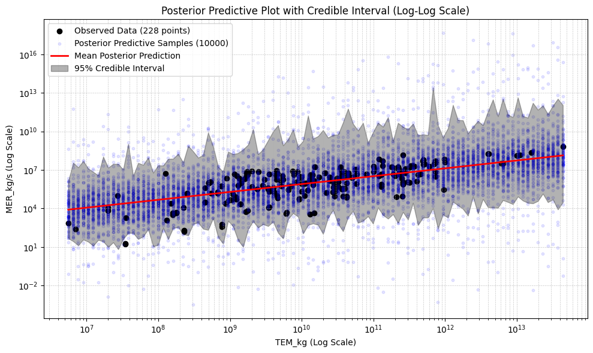

```
Predictions saved to predicted_mer.csv
```

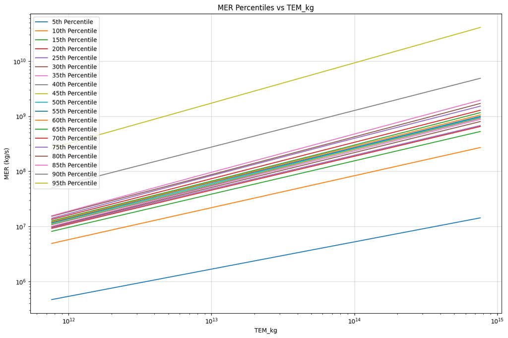

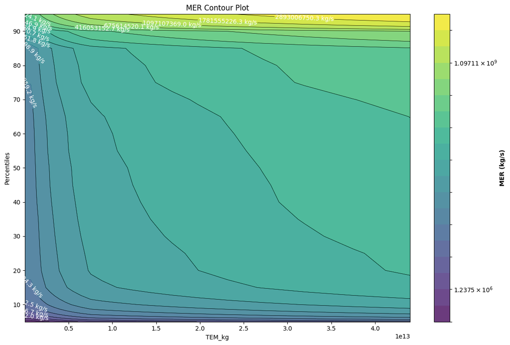

```python
from mer_predict import MERPredictor

tem_values=data.Mass_95th.to_list()




#tem_values=[1.998468e+11 , 3.585472e+14 ]



model = MERPredictor(aubrey_datacombined)

percentiles=list(range(5, 96, 5))

model.plot_posterior_predictive()
mer_results=model.predict_mer(tem_values, percentiles=percentiles)
#model.plot_percentiles_vs_tem()
# durations = model.convert_percentiles_to_duration(tem_values)
# print(durations)
```